# Árboles de decisión

Author

Dante Conti, Sergi Ramirez, (c) IDEAI

# 1 Descripción del problema

- *“ASSETID” :* Identificador único del activo
- *“PERIOD” :* Fecha AAAAMM, indica el trimestre en el que se extrajo el anuncio, utilizamos AAAA03 para el 1.er trimestre, AAAA06 para el 2.º, AAAA09 para el 3.er y AAAA12 para el 4.º
- *“PRICE” :* Precio de venta del anuncio en idealista expresado en euros
- *“UNITPRICE” :* Precio en euros por metro cuadrado
- *“CONSTRUCTEDAREA” :* Superficie construida de la casa en metros cuadrados
- *“ROOMNUMBER” :* Número de habitaciones
- *“BATHNUMBER” :* Número de baños
- *“HASTERRACE” :* Variable ficticia para terraza (toma 1 si hay una terraza, 0 en caso contrario)
- *“HASLIFT” :* Variable ficticia para ascensor (toma 1 si hay ascensor en el edificio, 0 en caso contrario)
- *“HASAIRCONDITIONING” :* Variable ficticia para Aire Acondicionado (toma 1 si hay una Aire Acondicionado, 0 en caso contrario)
- *“AMENITYID” :* Indica las comodidades incluidas (1 - sin muebles, sin comodidades de cocina, 2 - comodidades de cocina, sin muebles, 3 - comodidades de cocina, muebles)
- *“HASPARKINGSPACE” :* Variable ficticia para estacionamiento (toma 1 si el estacionamiento está incluido en el anuncio, 0 en caso contrario)
- *“ISPARKINGSPACEINCLUDEDINPRICE” :* Variable ficticia para estacionamiento (toma 1 si el estacionamiento está incluido en el anuncio, 0 en caso contrario)
- *“PARKINGSPACEPRICE” :* Precio de plaza de parking en euros
- *“HASNORTHORIENTATION” :* Variable ficticia para orientación (toma 1 si la orientación es Norte en el anuncio, 0 en caso contrario) - *Nota importante: las características de orientación no son características ortogonales, una casa orientada al norte también puede estar orientada al este*
- *“HASSOUTHORIENTATION” :* Variable ficticia para orientación (toma 1 si la orientación es Sur en el anuncio, 0 en caso contrario) - *Nota importante: las características de orientación no son características ortogonales, una casa orientada al norte también puede estar orientada al este*
- *“HASEASTORIENTATION” :* Variable ficticia para orientación (toma 1 si la orientación es Este en el anuncio, 0 en caso contrario) - *Nota importante: las características de orientación no son características ortogonales, una casa orientada al norte también puede estar orientada al este*
- *“HASWESTORIENTATION” :* Variable ficticia para orientación (toma 1 si la orientación es Oeste en el anuncio, 0 en caso contrario) - *Nota importante: las características de orientación no son características ortogonales, una casa orientada al norte también puede estar orientada al este*
- *“HASBOXROOM” :* Variable ficticia para boxroom (toma 1 si boxroom está incluido en el anuncio, 0 en caso contrario)
- *“HASWARDROBE” :* Variable ficticia para vestuario (toma 1 si el vestuario está incluido en el anuncio, 0 en caso contrario)
- *“HASSWIMMINGPOOL” :* Variable ficticia para piscina (toma 1 si la piscina está incluida en el anuncio, 0 en caso contrario)
- *“HASDOORMAN” :* Variable ficticia para portero (toma 1 si hay un portero en el edificio, 0 en caso contrario)
- *“HASGARDEN” :* Variable ficticia para jardín (toma 1 si hay un jardín en el edificio, 0 en caso contrario)
- *“ISDUPLEX” :* Variable ficticia para dúplex (toma 1 si es un dúplex, 0 en caso contrario)
- *“ISSTUDIO” :* Variable ficticia para piso de soltero (estudio en español) (toma 1 si es un piso para una sola persona, 0 en caso contrario)
- *“ISINTOPFLOOR” :* Variable ficticia que indica si el apartamento está ubicado en el piso superior (toma 1 en el piso superior, 0 en caso contrario)
- *“CONSTRUCTIONYEAR” :* Año de construcción (fuente: anunciante)
- *“FLOORCLEAN” :* Indica el número de piso del apartamento comenzando desde el valor 0 para la planta baja (fuente: anunciante)
- *“FLATLOCATIONID” :* Indica el tipo de vistas que tiene el piso (1 - exterior, 2 - interior)
- *“CADCONSTRUCTIONYEAR” :* Año de construcción según fuente catastral (fuente: catastro), tenga en cuenta que esta cifra puede diferir de la proporcionada por el anunciante
- *“CADMAXBUILDINGFLOOR” :* Superficie máxima del edificio (fuente: catastro)
- *“CADDWELLINGCOUNT” :* Recuento de viviendas en el edificio (fuente: catastro)
- *“CADASTRALQUALITYID” :* Calidad catastral (fuente: catastro)
- *“BUILTTYPEID_1” :* Valor ficticio para estado del piso: 1 obra nueva 0 en caso contrario (fuente: anunciante)
- *“BUILTTYPEID_2” :* Valor ficticio para condición plana: 1 segundero a restaurar 0 en caso contrario (fuente: anunciante)
- *“BUILTTYPEID_3” :* Valor ficticio para estado plano: 1 de segunda mano en buen estado 0 en caso contrario (fuente: anunciante)
- *“DISTANCE_TO_CITY_CENTER” :* Distancia al centro de la ciudad en km
- *“DISTANCE_TO_METRO” :* Distancia istancia a una parada de metro en km.
- *“DISTANCE_TO_DIAGONAL” :* Distancia a la Avenida Diagonal en km; Diagonal es una calle principal que corta la ciudad en diagonal a la cuadrícula de calles.
- *“LONGITUDE” :* Longitud del activo
- *“LATITUDE” :* Latitud del activo
- *“geometry” :* Geometría de características simples en latitud y longitud.

**Fuente**: [Idealista](https://www.idealista.com/)

**Mostrar código**

```r
library("idealista18")
BCN <- get(data("Barcelona_Sale"))
```

**Mostrar código**

```r
# Filtramos la epoca a Navidad
BCN <- BCN[which(BCN$PERIOD == "201812"), ]

pisos_sf_BCN <- st_as_sf(BCN, coords = c("LONGITUDE", "LATITUDE"), crs = 4326)

# Leer shapefile de secciones censales
secciones <- st_read("C:/Users/sergi/Downloads/Shapefile/seccionado_2024/SECC_CE_20240101.shp")

# Transformar pisos al sistema de referencia de las secciones censales
pisos_sf_BCN <- st_transform(pisos_sf_BCN, crs = st_crs(secciones))

# Hacer el match entre pisos y secciones censales
pisos_con_seccion <- st_join(pisos_sf_BCN, secciones, join = st_within)

# Convertir a dataframe para exportar
BCN <- as.data.frame(pisos_con_seccion)

rm(Barcelona_Sale, Barcelona_Polygons, Barcelona_POIS, pisos_con_seccion, pisos_sf_BCN, secciones); gc()
```

**Mostrar código**

```r
rentaMedia <- read.csv("https://raw.githubusercontent.com/miguel-angel-monjas/spain-datasets/refs/heads/master/data/Renta%20media%20en%20Espa%C3%B1a.csv")
# NOs quedamos con los datos que nos interesa de Barcelona
rentaMedia <- rentaMedia[which(rentaMedia$Provincia == "Barcelona" & rentaMedia$Tipo.de.elemento == "sección"), ]
rentaMedia$Código.de.territorio <- paste0("0", rentaMedia$Código.de.territorio)
```

**Mostrar código**

```r
cols <- c("Renta.media.por.persona", "Renta.media.por.hogar")

m <- match(BCN$CUSEC, rentaMedia$Código.de.territorio)
BCN[, cols] <- rentaMedia[m, cols]
```

# 2 Preprocessing de los datos

**Mostrar código**

```r
BCN <- BCN %>%
  select(-X, -PRICE, -LONGITUDE, -LATITUDE, -geometry, -CONSTRUCTIONYEAR,
         -ASSETID, -PERIOD, -CUSEC, -CSEC, -CMUN, -CPRO, -CCA, -CUDIS, -CLAU2,
         -NPRO, -NCA, -CNUT0, -CNUT1, -CNUT2, -CNUT3, -NMUN, -Shape_Leng,
         -Shape_Area, -geometry, -CUMUN, -CADASTRALQUALITYID) %>%
  mutate(
    across(
      .cols = starts_with(c("HAS", "IS")),
      .fns = ~ case_when(. == 0 ~ "No", . == 1 ~ "Si"),
      .names = "{.col}"),
    AMENITYID = case_when(
      AMENITYID == 1 ~ "SinMuebleSinCocina", AMENITYID == 2 ~ "CocinaSinMuebles",
      AMENITYID == 3 ~ "CocinaMuebles"),
    FLATLOCATIONID = case_when(
      FLATLOCATIONID == 1 ~ "exterior", FLATLOCATIONID == 2 ~ "interior",
      .default = "noInfo"),
    BUILTTYPEID_1 = case_when(
      BUILTTYPEID_1 == 0 ~ "noObraNueva", BUILTTYPEID_1 == 1 ~ "obraNueva"),
    BUILTTYPEID_2 = case_when(
      BUILTTYPEID_2 == 0 ~ "noRestaurar", BUILTTYPEID_2 == 1 ~ "Restaurar"),
    BUILTTYPEID_3 = case_when(
      BUILTTYPEID_3 == 0 ~ "noSegundaMano", BUILTTYPEID_3 == 1 ~ "SegundaMano"),
    FLOORCLEAN = replace_na(FLOORCLEAN, 0),
    CDIS = case_when(
      CDIS == 1 ~ "Ciutat-Vella", CDIS == 2 ~ "Eixample", CDIS == 3 ~ "Sants-Montjuic",
      CDIS == 4 ~ "Les Corts", CDIS == 5 ~ "Sarrià-Sant Gervasi",
      CDIS == 6 ~ "Gràcia", CDIS == 7 ~ "Horta-Guinardó", CDIS == 8 ~ "Nou Barris",
      CDIS == 9 ~ "Sant Andreu", CDIS == 10 ~ "Sant Martí"),
    RENTA = case_when(
     Renta.media.por.hogar < 30000 ~ "Baja",
     Renta.media.por.hogar >= 30000 & Renta.media.por.hogar <= 50000 ~ "Media",
     Renta.media.por.hogar > 50000 ~ "Alta"
    )
  ) %>%
  select(-Renta.media.por.hogar, -Renta.media.por.persona)
```

## 2.1 Análisi descriptivo de los datos

**Mostrar código**

```r
## Descriptiva de los datos
library(DataExplorer)
library(lubridate)
library(dplyr)

## Data Manipulation
library(reshape2)

## Plotting
library(ggplot2)

## Descripción completa
DataExplorer::introduce(BCN)
```

| rows | columns | discrete_columns | continuous_columns | all_missing_columns | total_missing_values | complete_rows | total_observations | memory_usage |
| --- | --- | --- | --- | --- | --- | --- | --- | --- |
| 23334 | 36 | 24 | 12 | 0 | 0 | 23334 | 840024 | 6078888 |

**Mostrar código**

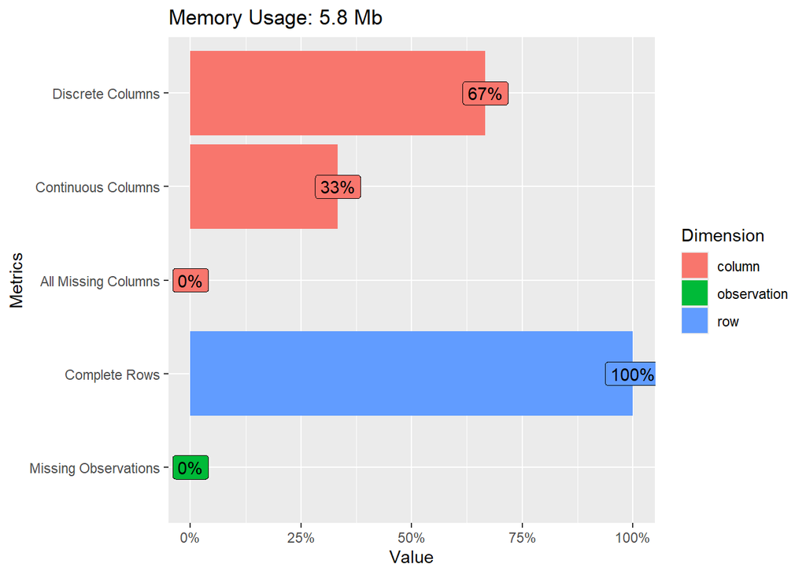

```r
## Descripción de la bbdd
plot_intro(BCN)
```

**Mostrar código**

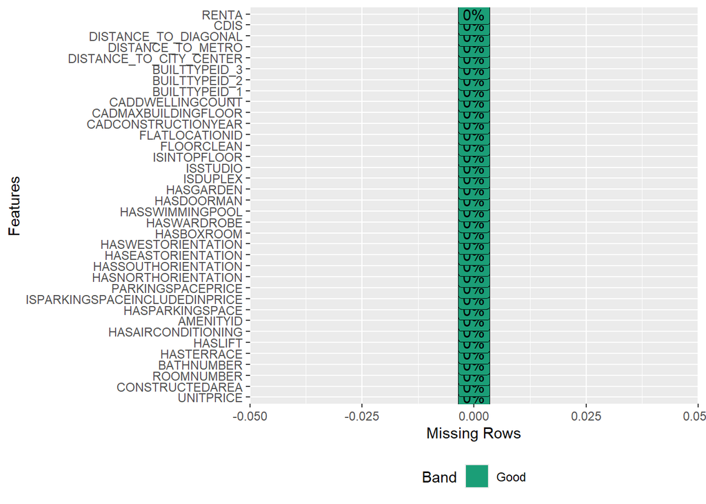

```r
## Descripción de los missings
plot_missing(BCN)
```

**Mostrar código**

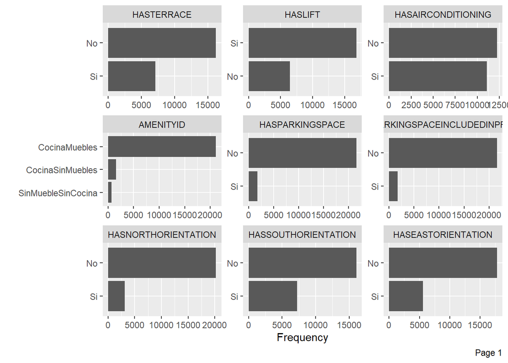

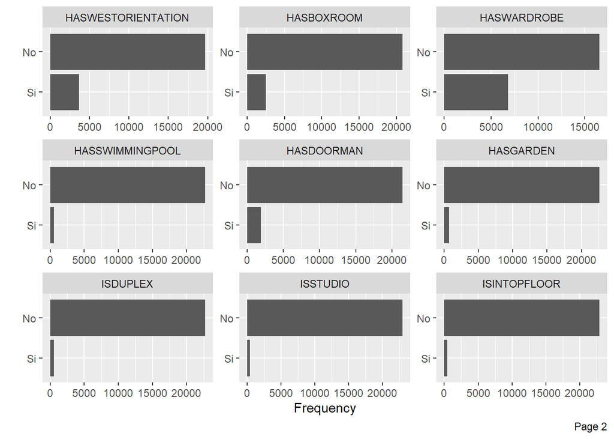

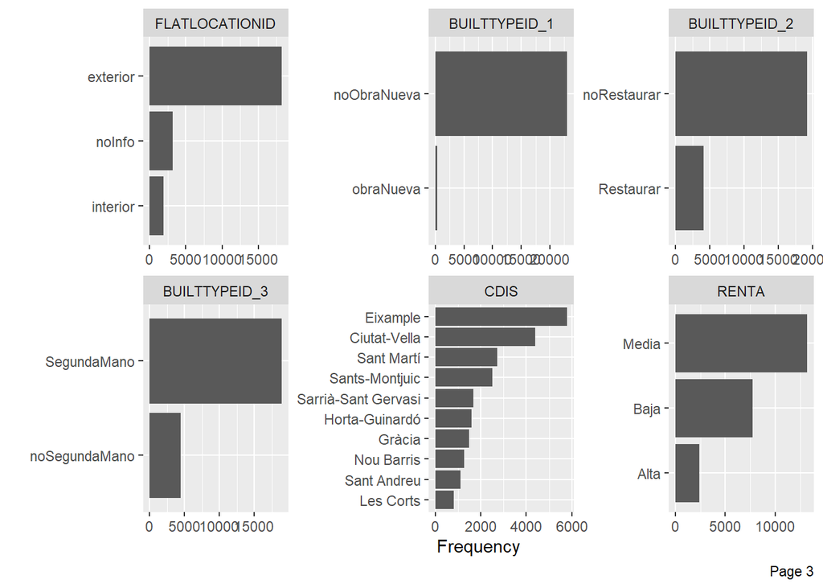

```r
## Descripción de las varaibles categoricas
plot_bar(BCN)
```

**Mostrar código**

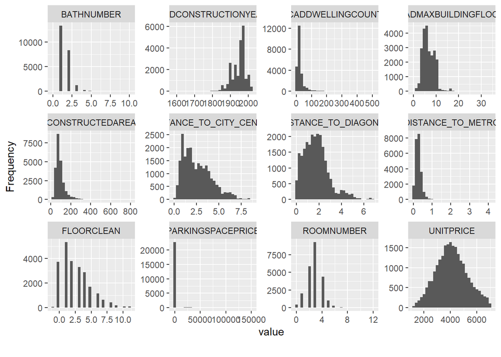

```r
## Descripción variables numéricas
plot_histogram(BCN)
```

**Mostrar código**

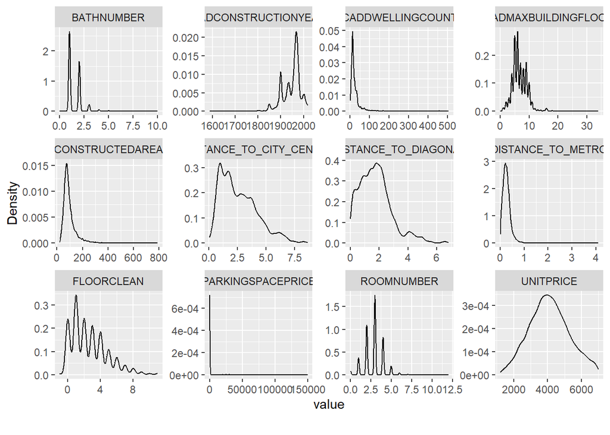

```r
plot_density(BCN)
```

**Mostrar código**

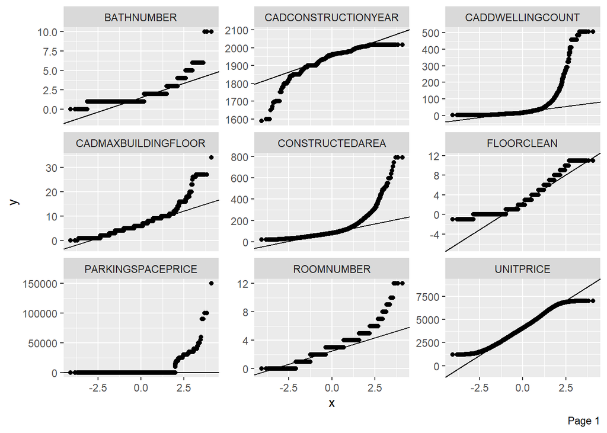

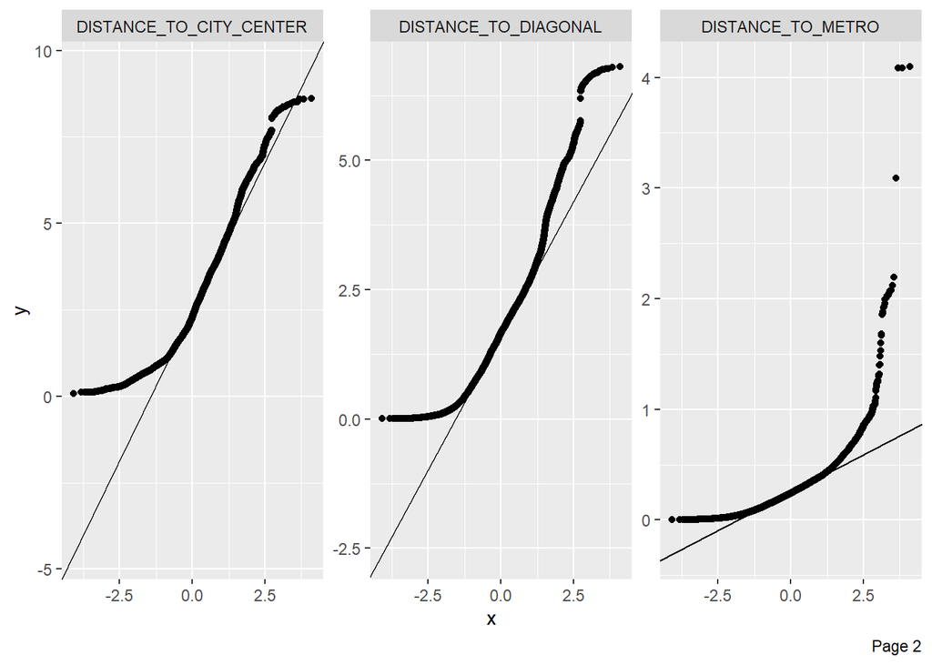

```r
plot_qq(BCN)
```

**Mostrar código**

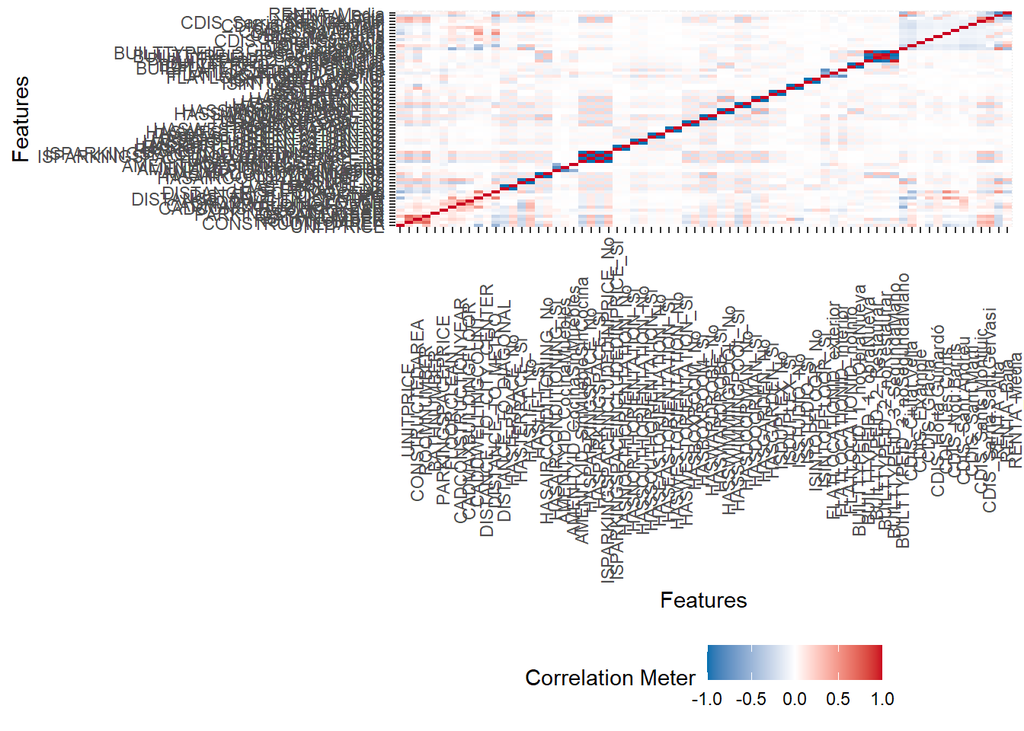

```r
plot_correlation(BCN)
```

# 3 Data Manipulation

**R**

**Mostrar código**

```r
library(caret)

set.seed(1994)

index <- caret::createDataPartition(BCN$UNITPRICE, p = 0.8, list = FALSE)
rtrain <- BCN %>% slice(index) %>% na.omit()
rtest <- BCN %>% slice(-index) %>% na.omit()
```

**Python**

**Mostrar código**

```python
from sklearn.preprocessing import LabelEncoder

# Crear un LabelEncoder
le = LabelEncoder()

# Lista de variables a transformar
columns_to_encode = ['HASTERRACE', 'HASLIFT', 'HASAIRCONDITIONING', 'AMENITYID',
    'HASPARKINGSPACE', 'ISPARKINGSPACEINCLUDEDINPRICE', 'HASNORTHORIENTATION',
    'HASSOUTHORIENTATION', 'HASEASTORIENTATION', 'HASWESTORIENTATION',
    'HASBOXROOM', 'HASWARDROBE', 'HASSWIMMINGPOOL', 'HASDOORMAN', 'HASGARDEN',
    'ISDUPLEX', 'ISSTUDIO', 'ISINTOPFLOOR', 'FLOORCLEAN', 'FLATLOCATIONID',
    'CADMAXBUILDINGFLOOR', 'CADDWELLINGCOUNT','BUILTTYPEID_1', 'BUILTTYPEID_2',
    'BUILTTYPEID_3', 'CDIS', 'RENTA']

# Aplicar LabelEncoder a cada columna de la lista
for col in columns_to_encode:
    if col in pyBCN.columns:  # Verificar que la columna existe en el DataFrame
        pyBCN[col] = le.fit_transform(pyBCN[col].astype(str))  # Convertir a string si no es categórica
```

**Mostrar código**

```python
from sklearn.model_selection import train_test_split

# dividimos la base de datos
X = pyBCN.drop(columns=["RENTA"])

pyX_train, pyX_test, pyy_train, pyy_test = train_test_split(
    X, pyBCN['RENTA'], test_size = 0.2, random_state = 1994)
```

**Mostrar código**

```python
from sklearn.preprocessing import StandardScaler

# Scale dataset
sc = StandardScaler()
pyX_train = sc.fit_transform(pyX_train)
pyX_test = sc.fit_transform(pyX_test)
```

# 4 Árboles de decisión

## 4.1 Creación del árbol

**R**

**Mostrar código**

```r
library(rpart)
library(rpart.plot)

set.seed(1994)

arbol <- rpart(RENTA ~ ., data = rtrain)
summary(arbol)
```

```
Call:
rpart(formula = RENTA ~ ., data = rtrain)
  n= 18669

          CP nsplit rel error    xerror        xstd
1 0.38211183      0 1.0000000 1.0000000 0.008293935
2 0.06753946      1 0.6178882 0.6178882 0.007426365
3 0.04447571      2 0.5503487 0.5503487 0.007149373
4 0.02214609      4 0.4613973 0.4643338 0.006727872
5 0.01884253      5 0.4392512 0.4425548 0.006607381
6 0.01186835      6 0.4204087 0.4267711 0.006516230
7 0.01162364      8 0.3966720 0.4034014 0.006375036
8 0.01015539     10 0.3734247 0.3792977 0.006221129
9 0.01000000     12 0.3531139 0.3676740 0.006143722

Variable importance
                   CDIS DISTANCE_TO_CITY_CENTER    DISTANCE_TO_DIAGONAL
                     40                      24                      17
    CADCONSTRUCTIONYEAR         CONSTRUCTEDAREA               UNITPRICE
                      8                       3                       3
      DISTANCE_TO_METRO              BATHNUMBER              ROOMNUMBER
                      2                       1                       1

Node number 1: 18669 observations,    complexity param=0.3821118
  predicted class=Media  expected loss=0.4377846  P(node) =1
    class counts:  1941  6232 10496
   probabilities: 0.104 0.334 0.562
  left son=2 (4541 obs) right son=3 (14128 obs)
  Primary splits:
      CDIS                    splits as  LRRRRLRRRR, improve=2615.4350, (0 missing)
      DISTANCE_TO_DIAGONAL    < 1.697581   to the right, improve=1710.4180, (0 missing)
      HASLIFT                 splits as  LR, improve= 961.7684, (0 missing)
      DISTANCE_TO_CITY_CENTER < 1.146692   to the left,  improve= 885.2803, (0 missing)
      CADCONSTRUCTIONYEAR     < 1900.5     to the left,  improve= 800.8061, (0 missing)
  Surrogate splits:
      DISTANCE_TO_CITY_CENTER < 1.146692   to the left,  agree=0.853, adj=0.396, (0 split)
      CADCONSTRUCTIONYEAR     < 1900.5     to the left,  agree=0.823, adj=0.273, (0 split)
      DISTANCE_TO_DIAGONAL    < 4.28574    to the right, agree=0.775, adj=0.076, (0 split)
      CONSTRUCTEDAREA         < 46.5       to the left,  agree=0.769, adj=0.052, (0 split)
      ROOMNUMBER              < 11         to the right, agree=0.757, adj=0.001, (0 split)
```

[output cut: 237 more lines]

```

Node number 57: 262 observations
  predicted class=Media  expected loss=0.2061069  P(node) =0.01403396
    class counts:     0    54   208
   probabilities: 0.000 0.206 0.794

Node number 60: 284 observations
  predicted class=Alta   expected loss=0.1584507  P(node) =0.01521238
    class counts:   239     0    45
   probabilities: 0.842 0.000 0.158

Node number 61: 239 observations
  predicted class=Media  expected loss=0.041841  P(node) =0.01280197
    class counts:    10     0   229
   probabilities: 0.042 0.000 0.958
```

**Mostrar código**

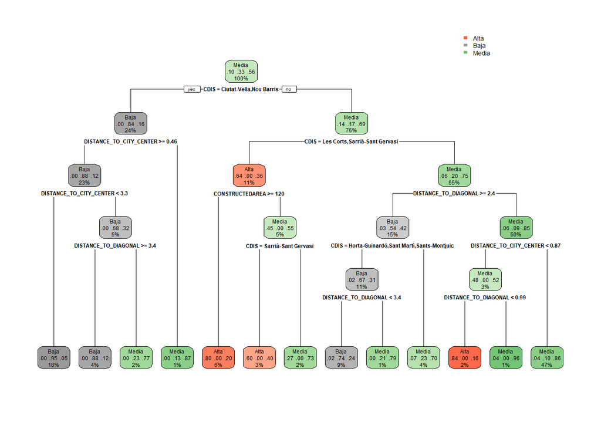

```r
rpart.plot(arbol)
```

**Python**

**Mostrar código**

```python
# Decision Tree Classification
from sklearn.tree import DecisionTreeClassifier

classifier = DecisionTreeClassifier(criterion = 'entropy', random_state = 1994)
clf = classifier.fit(pyX_train, pyy_train)
```

**Mostrar código**

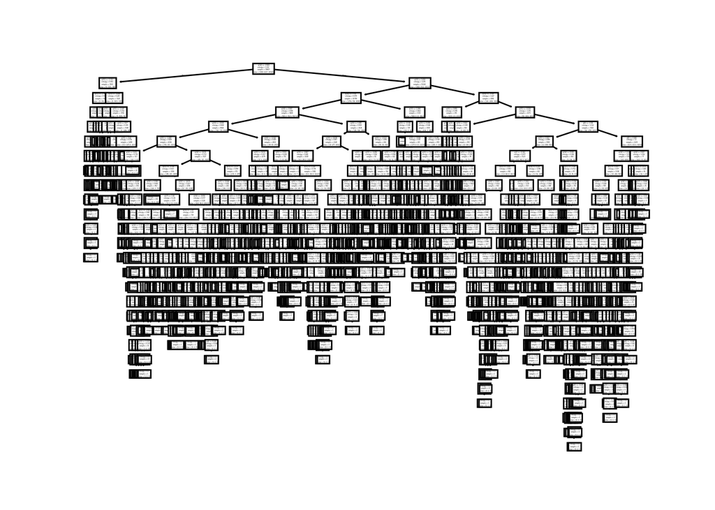

```python
from sklearn import tree

tree.plot_tree(clf)
```

## 4.2 Creamos las predicciones

**R**

Aplicamos el modelo a nuestros valores de test.

**Mostrar código**

```r
predict(arbol, rtest[1:10, ])
```

```
   Alta      Baja      Media
1     0 0.9469189 0.05308115
2     0 0.9469189 0.05308115
3     0 0.9469189 0.05308115
4     0 0.9469189 0.05308115
5     0 0.9469189 0.05308115
6     0 0.1336032 0.86639676
7     0 0.9469189 0.05308115
8     0 0.9469189 0.05308115
9     0 0.9469189 0.05308115
10    0 0.1336032 0.86639676
```

**Mostrar código**

```r
predicciones <- predict(arbol, rtrain, type = "class")
caret::confusionMatrix(predicciones, as.factor(rtrain$RENTA))
```

```
Confusion Matrix and Statistics

          Reference
Prediction Alta Baja Media
     Alta  1396    0   460
     Baja    35 5027   676
     Media  510 1205  9360

Overall Statistics

               Accuracy : 0.8454
                 95% CI : (0.8401, 0.8506)
    No Information Rate : 0.5622
    P-Value [Acc > NIR] : < 2.2e-16

                  Kappa : 0.7207

 Mcnemar's Test P-Value : < 2.2e-16

Statistics by Class:

                     Class: Alta Class: Baja Class: Media
Sensitivity              0.71922      0.8066       0.8918
Specificity              0.97250      0.9428       0.7902
Pos Pred Value           0.75216      0.8761       0.8451
Neg Pred Value           0.96758      0.9068       0.8504
Prevalence               0.10397      0.3338       0.5622
Detection Rate           0.07478      0.2693       0.5014
Detection Prevalence     0.09942      0.3074       0.5932
Balanced Accuracy        0.84586      0.8747       0.8410
```

**Mostrar código**

```r
predicciones <- predict(arbol, rtest, type = "class")
caret::confusionMatrix(predicciones, as.factor(rtest$RENTA))
```

```
Confusion Matrix and Statistics

          Reference
Prediction Alta Baja Media
     Alta   311    1   148
     Baja     5 1250   171
     Media  151  266  2362

Overall Statistics

               Accuracy : 0.8409
                 95% CI : (0.8301, 0.8513)
    No Information Rate : 0.5747
    P-Value [Acc > NIR] : < 2.2e-16

                  Kappa : 0.7099

 Mcnemar's Test P-Value : 3.415e-05

Statistics by Class:

                     Class: Alta Class: Baja Class: Media
Sensitivity              0.66595      0.8240       0.8810
Specificity              0.96451      0.9441       0.7898
Pos Pred Value           0.67609      0.8766       0.8499
Neg Pred Value           0.96290      0.9176       0.8309
Prevalence               0.10011      0.3252       0.5747
Detection Rate           0.06667      0.2680       0.5063
Detection Prevalence     0.09861      0.3057       0.5957
Balanced Accuracy        0.81523      0.8840       0.8354
```

**Mostrar código**

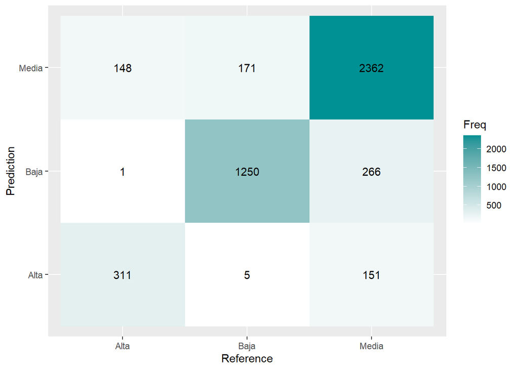

```r
CM <- caret::confusionMatrix(predicciones, as.factor(rtest$RENTA)); CM <- data.frame(CM$table)

grafico <- ggplot(CM, aes(Prediction,Reference, fill= Freq)) +
        geom_tile() + geom_text(aes(label=Freq)) +
        scale_fill_gradient(low="white", high="#009194") +
        labs(x = "Reference",y = "Prediction")

plot(grafico)
```

**Python**

**Mostrar código**

```python
import pandas as pd

# Prediction
y_pred = classifier.predict(pyX_test)

results = pd.DataFrame({
    'Real': pyy_test,  # Valores reales
    'Predicho': y_pred  # Valores predichos
})

# Muestra los primeros 5 registros
print(results.head())
```

```
       Real  Predicho
2399      2         2
18420     0         0
22515     2         2
20265     1         1
10432     1         1
```

**Mostrar código**

```python
from sklearn.metrics import classification_report

print(f'Classification Report: \n{classification_report(pyy_test, y_pred)}')
```

```
Classification Report:
              precision    recall  f1-score   support

           0       0.85      0.82      0.84       488
           1       0.92      0.91      0.91      1522
           2       0.92      0.93      0.92      2657

    accuracy                           0.91      4667
   macro avg       0.89      0.89      0.89      4667
weighted avg       0.91      0.91      0.91      4667
```

**Mostrar código**

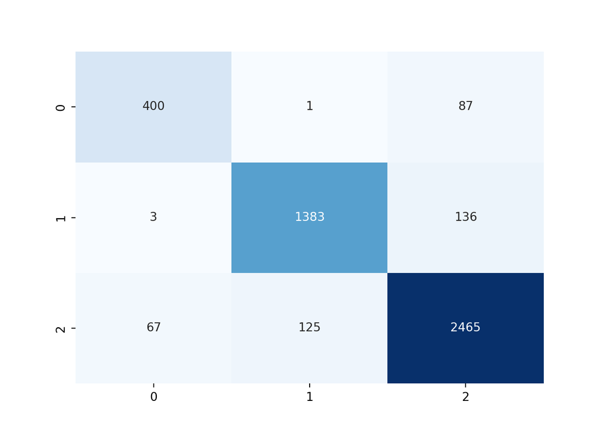

```python
from sklearn.metrics import confusion_matrix
import seaborn as sns

# Confusion matrix
cf_matrix = confusion_matrix(pyy_test, y_pred)
sns.heatmap(cf_matrix, annot=True, fmt='d', cmap='Blues', cbar=False)
```